# Running a MAUT Model

Pedro Guarderas

October 25, 2023

## Introduction

The decision models based in *Multi Attribute Utility Theory* (MAUT) are defined with aid of utility functions $u_1,\ldots,u_n$ which are evaluated over indexes $x_1,\ldots,x_n$ and those utilities are aggregated considering additional weights $w_1,\ldots,w_n$, the whole final utility is given by the sum
$$u(x_1,\ldots,x_n) =
\sum_{i=1}^n\, w_i\, u_i\ ( x_i )$$
every utility $u_i$ can be normalized to take values only between $0$ and $1$.

A model based in MAUT additionally has a decision tree that represents the relations between subsets of utilities, given an ordered and conceptual development of the decision model.

This **mau** package is designed to implement and test decision models based in (MAUT).

## Utility definition

The utility functions for a MAUT model could be defined in a practical format when the utilities are *piecewise defined* like *Constant Risk Averse Utilities* (CRAU for short), satisfying the equation:
$$\frac{u''}{u'} =
\lambda$$
being $\lambda$ a constant. The previous equation only admits two kind of solutions, $u(x) = a \cdot x + b$ or $u(x) = a \cdot e^{b \cdot x} + c$. To completely determine an utility, it is only necessary to know the three parameters $a,b,c$. Additionally, the following convention is assumed, if $c$ is $0$ then the utility is linear otherwise is an exponential function.

For piecewise CRAU, it is only necessary to define the parameters $a,b,c$ of the function for each part of the domain of definition. The **mau** package could load the utilities from an standardized text file with the following internal structure.

The capabilities of **mau** are not only restricted to work with CRAU class, you can define any utility by employing the correct R script.

> Header

> Function name  
> min1 max1 a1 b1 c1  
> min2 max2 a2 b2 c2  
> min3 max3 a3 b3 c3  
> …  
> Function name  
> min1 max1 a1 b1 c1  
> min2 max2 a2 b2 c2  
> min3 max3 a3 b3 c3  
> …

Here an example of the structure of the standardized file for utility definitions

```r
library( mau )
file <- system.file( "extdata", "utilities.txt", package = "mau" )
lines <- readLines( file )
for ( i in 1:length( lines ) ) {
  cat( lines[i], '\n' )
}
```

```
## Utilities
##
## Project
##  1   2   1.5 -0.5    0
##  2   3   1.5 -0.5    0
##
## Self implementation
##  1   2   1.5 -0.5    0
##  2   3   1.5 -0.5    0
##
## External and local relations
##  1   10  1   0   0
##  0   1   0   1   0
##
## Scope of capabilities
##  6   15  1   0   0
##  0   6   1.225   -1.225  0.2824
```

## Main example

In the sources below is developed a complete example of a MAUT model, the package **mau** is employed to load utilities defined in the file `utilities.txt`, automatically the script with utilities is built and saved in the local working directory, after that with `eval_utilities` every function is evaluated over the columns of the index table, the names for utilities were previously standardized with `stand_string`. With another file `tree.csv` the decision tree associated to the MAUT model is built and every weight and relative weight assigned with the `make_decision_tree` function, in addition the whole model with utilities of every criteria is obtained with `compute_model`. The simulation of constrained weights is made with `sim_const_weights`, the result could be employed for a sensitivity test of the decision model regarding concentrated weights variation.

1. Loading necessary packages

```r
library( mau )
library( data.table )
library( igraph )
library( ggplot2 )
```

2. Index definition

```r
index <- data.table( cod = paste( 'A', 1:10, sep = '' ),
                     i1 = c( 0.34, 1, 1, 1, 1, 0.2, 0.7, 0.5, 0.11, 0.8 ),
                     i2 = c( 0.5, 0.5, 1, 0.5, 0.3, 0.1, 0.4, 0.13, 1, 0.74 ),
                     i3 = c( 0.5, 1.0, 0.75, 0.25, 0.1, 0.38, 0.57, 0.97, 0.3, 0.76 ),
                     i4 = c( 0, 0.26, 0.67, 0.74, 0.84, 0.85, 0.74, 0.65, 0.37, 0.92 ) )
```

| cod | i1 | i2 | i3 | i4 |
| --- | --- | --- | --- | --- |
| A1 | 0.34 | 0.50 | 0.50 | 0.00 |
| A2 | 1.00 | 0.50 | 1.00 | 0.26 |
| A3 | 1.00 | 1.00 | 0.75 | 0.67 |
| A4 | 1.00 | 0.50 | 0.25 | 0.74 |
| A5 | 1.00 | 0.30 | 0.10 | 0.84 |
| A6 | 0.20 | 0.10 | 0.38 | 0.85 |
| A7 | 0.70 | 0.40 | 0.57 | 0.74 |
| A8 | 0.50 | 0.13 | 0.97 | 0.65 |
| A9 | 0.11 | 1.00 | 0.30 | 0.37 |
| A10 | 0.80 | 0.74 | 0.76 | 0.92 |

3. Loading file with utilities

```r
file <- system.file( "extdata", "utilities.txt", package = "mau" )
lines <- 17
skip <- 2
encoding <- 'utf-8'
functions <- read_utilities( file, lines, skip, encoding )
# script <- 'utilities.R'
# write( functions[[ 2 ]], script )
functions <- functions[[ 1 ]]
```

The `functions` data.table has the following structure with the piecewise definition of CRAU’s

| nom | min | max | a | b | c | fun |
| --- | --- | --- | --- | --- | --- | --- |
| External and local relations | 0 | 1 | 0.000 | 1.000 | 0.0000 | external_local_relations |
| External and local relations | 1 | 10 | 1.000 | 0.000 | 0.0000 | external_local_relations |
| Project | 1 | 2 | 1.500 | -0.500 | 0.0000 | project |
| Project | 2 | 3 | 1.500 | -0.500 | 0.0000 | project |
| Scope of capabilities | 0 | 6 | 1.225 | -1.225 | 0.2824 | scope_capabilities |
| Scope of capabilities | 6 | 15 | 1.000 | 0.000 | 0.0000 | scope_capabilities |
| Self implementation | 1 | 2 | 1.500 | -0.500 | 0.0000 | self_implementation |
| Self implementation | 2 | 3 | 1.500 | -0.500 | 0.0000 | self_implementation |

3. Evaluation of utilities over every index

```r
# Index positions
columns <- c( 2, 3, 4, 5 )

# Function names
functions <- sapply( c( 'Project',
                        'Self implementation',
                        'External and local relations',
                        'Scope of capabilities' ),
                     FUN = stand_string )
names( functions ) <- NULL

# Evaluation of utilities
utilities <- eval_utilities( index, columns, functions )
```

The `utilities` data.table has the following structure

| cod | u1 | u2 | u3 | u4 |
| --- | --- | --- | --- | --- |
| A1 | 0 | 0 | 0.50 | 0.0000000 |
| A2 | 1 | 0 | 1.00 | 0.0867217 |
| A3 | 1 | 1 | 0.75 | 0.2111724 |
| A4 | 1 | 0 | 0.25 | 0.2310170 |
| A5 | 1 | 0 | 0.10 | 0.2586944 |
| A6 | 0 | 0 | 0.38 | 0.2614194 |
| A7 | 0 | 0 | 0.57 | 0.2310170 |
| A8 | 0 | 0 | 0.97 | 0.2054301 |
| A9 | 0 | 1 | 0.30 | 0.1215376 |
| A10 | 0 | 0 | 0.76 | 0.2802804 |

4. Construction of the decision tree

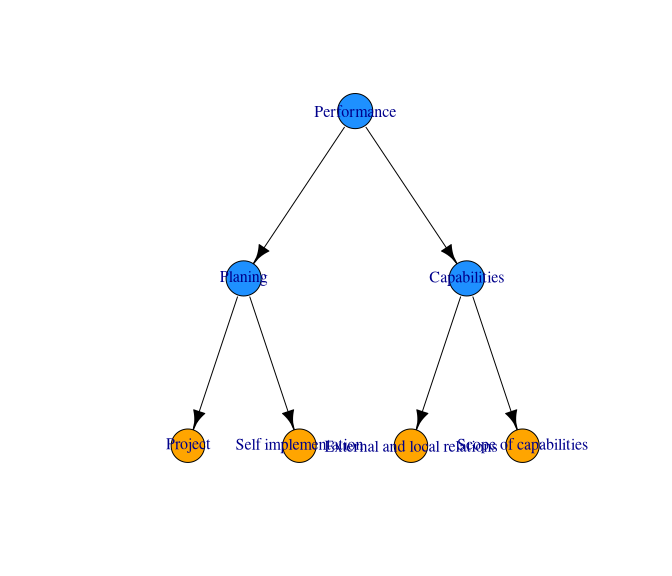

```r
file <- system.file("extdata", "tree.csv", package = "mau" )
tree.data <- read_tree( file, skip = 0, nrow = 8 )
tree <- make_decision_tree( tree.data )
utilities <- eval_utilities( index, columns, functions )

plot( tree, layout = layout_as_tree )
```

5. Computing the decision model

```r
weights <- tree.data[ !is.na( weight ) ]$weight
model <- compute_model( tree, utilities, weights )
```

| id | name | cod | index | deep | utility | relative.utility | weight | relative.weight |
| --- | --- | --- | --- | --- | --- | --- | --- | --- |
| 1 | Performance | A1 | NA | 0 | 0.0500000 | 0.0500000 | 1.0 | 1.0000000 |
| 1 | Performance | A2 | NA | 0 | 0.3173443 | 0.3173443 | 1.0 | 1.0000000 |
| 1 | Performance | A3 | NA | 0 | 0.8172345 | 0.8172345 | 1.0 | 1.0000000 |
| 1 | Performance | A4 | NA | 0 | 0.2712034 | 0.2712034 | 1.0 | 1.0000000 |
| 1 | Performance | A5 | NA | 0 | 0.2617389 | 0.2617389 | 1.0 | 1.0000000 |
| 1 | Performance | A6 | NA | 0 | 0.0902839 | 0.0902839 | 1.0 | 1.0000000 |
| 1 | Performance | A7 | NA | 0 | 0.1032034 | 0.1032034 | 1.0 | 1.0000000 |
| 1 | Performance | A8 | NA | 0 | 0.1380860 | 0.1380860 | 1.0 | 1.0000000 |
| 1 | Performance | A9 | NA | 0 | 0.5543075 | 0.5543075 | 1.0 | 1.0000000 |
| 1 | Performance | A10 | NA | 0 | 0.1320561 | 0.1320561 | 1.0 | 1.0000000 |
| 2 | Planing | A1 | NA | 1 | 0.0000000 | 0.0000000 | 0.7 | 0.7000000 |
| 2 | Planing | A2 | NA | 1 | 0.2000000 | 0.2857143 | 0.7 | 0.7000000 |
| 2 | Planing | A3 | NA | 1 | 0.7000000 | 1.0000000 | 0.7 | 0.7000000 |
| 2 | Planing | A4 | NA | 1 | 0.2000000 | 0.2857143 | 0.7 | 0.7000000 |
| 2 | Planing | A5 | NA | 1 | 0.2000000 | 0.2857143 | 0.7 | 0.7000000 |
| 2 | Planing | A6 | NA | 1 | 0.0000000 | 0.0000000 | 0.7 | 0.7000000 |
| 2 | Planing | A7 | NA | 1 | 0.0000000 | 0.0000000 | 0.7 | 0.7000000 |
| 2 | Planing | A8 | NA | 1 | 0.0000000 | 0.0000000 | 0.7 | 0.7000000 |
| 2 | Planing | A9 | NA | 1 | 0.5000000 | 0.7142857 | 0.7 | 0.7000000 |
| 2 | Planing | A10 | NA | 1 | 0.0000000 | 0.0000000 | 0.7 | 0.7000000 |
| 3 | Capabilities | A1 | NA | 1 | 0.0500000 | 0.1666667 | 0.3 | 0.3000000 |
| 3 | Capabilities | A2 | NA | 1 | 0.1173443 | 0.3911478 | 0.3 | 0.3000000 |
| 3 | Capabilities | A3 | NA | 1 | 0.1172345 | 0.3907816 | 0.3 | 0.3000000 |
| 3 | Capabilities | A4 | NA | 1 | 0.0712034 | 0.2373447 | 0.3 | 0.3000000 |
| 3 | Capabilities | A5 | NA | 1 | 0.0617389 | 0.2057963 | 0.3 | 0.3000000 |
| 3 | Capabilities | A6 | NA | 1 | 0.0902839 | 0.3009463 | 0.3 | 0.3000000 |
| 3 | Capabilities | A7 | NA | 1 | 0.1032034 | 0.3440113 | 0.3 | 0.3000000 |
| 3 | Capabilities | A8 | NA | 1 | 0.1380860 | 0.4602868 | 0.3 | 0.3000000 |
| 3 | Capabilities | A9 | NA | 1 | 0.0543075 | 0.1810251 | 0.3 | 0.3000000 |
| 3 | Capabilities | A10 | NA | 1 | 0.1320561 | 0.4401870 | 0.3 | 0.3000000 |
| 4 | Project | A1 | 1 | 2 | 0.0000000 | 0.0000000 | 0.2 | 0.2857143 |
| 4 | Project | A2 | 1 | 2 | 0.2000000 | 1.0000000 | 0.2 | 0.2857143 |
| 4 | Project | A3 | 1 | 2 | 0.2000000 | 1.0000000 | 0.2 | 0.2857143 |
| 4 | Project | A4 | 1 | 2 | 0.2000000 | 1.0000000 | 0.2 | 0.2857143 |
| 4 | Project | A5 | 1 | 2 | 0.2000000 | 1.0000000 | 0.2 | 0.2857143 |
| 4 | Project | A6 | 1 | 2 | 0.0000000 | 0.0000000 | 0.2 | 0.2857143 |
| 4 | Project | A7 | 1 | 2 | 0.0000000 | 0.0000000 | 0.2 | 0.2857143 |
| 4 | Project | A8 | 1 | 2 | 0.0000000 | 0.0000000 | 0.2 | 0.2857143 |
| 4 | Project | A9 | 1 | 2 | 0.0000000 | 0.0000000 | 0.2 | 0.2857143 |
| 4 | Project | A10 | 1 | 2 | 0.0000000 | 0.0000000 | 0.2 | 0.2857143 |
| 5 | Self implementation | A1 | 2 | 2 | 0.0000000 | 0.0000000 | 0.5 | 0.7142857 |
| 5 | Self implementation | A2 | 2 | 2 | 0.0000000 | 0.0000000 | 0.5 | 0.7142857 |
| 5 | Self implementation | A3 | 2 | 2 | 0.5000000 | 1.0000000 | 0.5 | 0.7142857 |
| 5 | Self implementation | A4 | 2 | 2 | 0.0000000 | 0.0000000 | 0.5 | 0.7142857 |
| 5 | Self implementation | A5 | 2 | 2 | 0.0000000 | 0.0000000 | 0.5 | 0.7142857 |
| 5 | Self implementation | A6 | 2 | 2 | 0.0000000 | 0.0000000 | 0.5 | 0.7142857 |
| 5 | Self implementation | A7 | 2 | 2 | 0.0000000 | 0.0000000 | 0.5 | 0.7142857 |
| 5 | Self implementation | A8 | 2 | 2 | 0.0000000 | 0.0000000 | 0.5 | 0.7142857 |
| 5 | Self implementation | A9 | 2 | 2 | 0.5000000 | 1.0000000 | 0.5 | 0.7142857 |
| 5 | Self implementation | A10 | 2 | 2 | 0.0000000 | 0.0000000 | 0.5 | 0.7142857 |
| 6 | External and local relations | A1 | 3 | 2 | 0.0500000 | 0.5000000 | 0.1 | 0.3333333 |
| 6 | External and local relations | A2 | 3 | 2 | 0.1000000 | 1.0000000 | 0.1 | 0.3333333 |
| 6 | External and local relations | A3 | 3 | 2 | 0.0750000 | 0.7500000 | 0.1 | 0.3333333 |
| 6 | External and local relations | A4 | 3 | 2 | 0.0250000 | 0.2500000 | 0.1 | 0.3333333 |
| 6 | External and local relations | A5 | 3 | 2 | 0.0100000 | 0.1000000 | 0.1 | 0.3333333 |
| 6 | External and local relations | A6 | 3 | 2 | 0.0380000 | 0.3800000 | 0.1 | 0.3333333 |
| 6 | External and local relations | A7 | 3 | 2 | 0.0570000 | 0.5700000 | 0.1 | 0.3333333 |
| 6 | External and local relations | A8 | 3 | 2 | 0.0970000 | 0.9700000 | 0.1 | 0.3333333 |
| 6 | External and local relations | A9 | 3 | 2 | 0.0300000 | 0.3000000 | 0.1 | 0.3333333 |
| 6 | External and local relations | A10 | 3 | 2 | 0.0760000 | 0.7600000 | 0.1 | 0.3333333 |
| 7 | Scope of capabilities | A1 | 4 | 2 | 0.0000000 | 0.0000000 | 0.2 | 0.6666667 |
| 7 | Scope of capabilities | A2 | 4 | 2 | 0.0173443 | 0.0867217 | 0.2 | 0.6666667 |
| 7 | Scope of capabilities | A3 | 4 | 2 | 0.0422345 | 0.2111724 | 0.2 | 0.6666667 |
| 7 | Scope of capabilities | A4 | 4 | 2 | 0.0462034 | 0.2310170 | 0.2 | 0.6666667 |
| 7 | Scope of capabilities | A5 | 4 | 2 | 0.0517389 | 0.2586944 | 0.2 | 0.6666667 |
| 7 | Scope of capabilities | A6 | 4 | 2 | 0.0522839 | 0.2614194 | 0.2 | 0.6666667 |
| 7 | Scope of capabilities | A7 | 4 | 2 | 0.0462034 | 0.2310170 | 0.2 | 0.6666667 |
| 7 | Scope of capabilities | A8 | 4 | 2 | 0.0410860 | 0.2054301 | 0.2 | 0.6666667 |
| 7 | Scope of capabilities | A9 | 4 | 2 | 0.0243075 | 0.1215376 | 0.2 | 0.6666667 |
| 7 | Scope of capabilities | A10 | 4 | 2 | 0.0560561 | 0.2802804 | 0.2 | 0.6666667 |

6. Bar plot for every utility

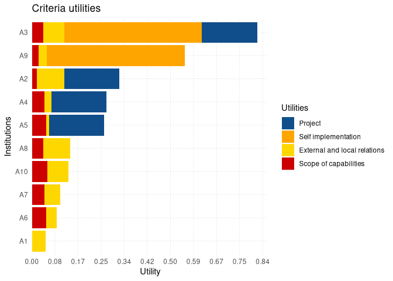

```r
xlab <- 'Utility'
ylab <- 'Institutions'
title <- 'Criteria utilities'

colors <- c( 'dodgerblue4', 'orange', 'gold', 'red3' )
deep <- 2
bar <- bar_plot( model, deep, colors, title, xlab, ylab )
plot( bar )
```

7. Sensitivity analysis under weights change. The weights are simulated employing a Dirichlet distribution.

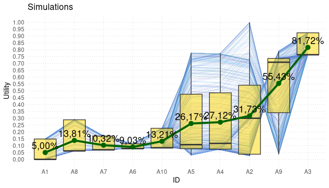

```r
n <- 800
alpha <- c( 0.2, 0.5, 0.1, 0.2 )
constraints <- list( list( c(1,2), 0.7 ),
                     list( c(3,4), 0.3 ) )
S <- sim_const_weights( n, utilities, alpha, constraints )
plot.S <- plot_sim_weight( S$simulation, title = 'Simulations',
                           xlab = 'ID', ylab = 'Utility' )
plot( plot.S )
```